# Impact of reference bundle on scRNA-Seq alignment

This the first part of analysis about the impact of reference bundle on scRNA-Seq alignment and gene quantifications. Alignment metrics have been parsed from `STAR` alignment log file `Final.out.log`. The metrics we will examine is `unique mapping reads`,`multiple mapping reads`, `reads mapped too many loci`, `total number of annotated junctions`.

First,load packages `ggplot2` and `plyr`

```r
library(ggplot2)
library(plyr)
```

Now take a look at the `STAR` logs.

```r
ref_log<-read.delim('~/Documents/HCA/reference/ref_run_MGH30_logs.tsv',sep='\t',header=T)
head(ref_log)
```

```
##        sraID length       ref_name  Started.job.on Started.mapping.on
## 1 SRR1294900     25 GRCh38_Ensembl Oct 26 22:08:13    Oct 26 22:17:39
## 2 SRR1294893     25 GRCh38_Ensembl Oct 26 22:08:40    Oct 26 22:17:57
## 3 SRR1294905     25 GRCh38_Ensembl Oct 26 22:08:51    Oct 26 22:18:51
## 4 SRR1294971     25 GRCh38_Ensembl Oct 26 22:08:45    Oct 26 22:18:17
## 5 SRR1294904     25 GRCh38_Ensembl Oct 26 22:08:43    Oct 26 22:18:17
## 6 SRR1294935     25 GRCh38_Ensembl Oct 26 22:08:36    Oct 26 22:18:15
##       Finished.on Mapping.speed..Million.of.reads.per.hour
## 1 Oct 26 22:18:41                                   243.37
## 2 Oct 26 22:18:59                                   235.83
## 3 Oct 26 22:19:46                                   222.83
## 4 Oct 26 22:19:33                                   253.75
## 5 Oct 26 22:19:19                                   231.13
## 6 Oct 26 22:19:32                                   253.78
##   Number.of.input.reads Average.input.read.length
```

[output cut: 97 more lines]

Then add string `bp` to column `length` and then rename of `ref_name`

```r
rlen<-paste(ref_log$length,'bp')
refname<-mapvalues(ref_log$ref_name,from=c('GRCh38_Ensembl','GRCh38_GencodeV27','GRCh38_GencodeV27_basic','GRCh38_RefSeq'),to=c('Ensembl','GencodeV27_comp','GencodeV27_basic','RefSeq'))
multi.loci<-unlist(lapply(ref_log$X..of.reads.mapped.to.multiple.loci, function(x) as.numeric(sub("%", "", x))))
ref_log$ref_name<-refname
ref_log$length<-rlen
```

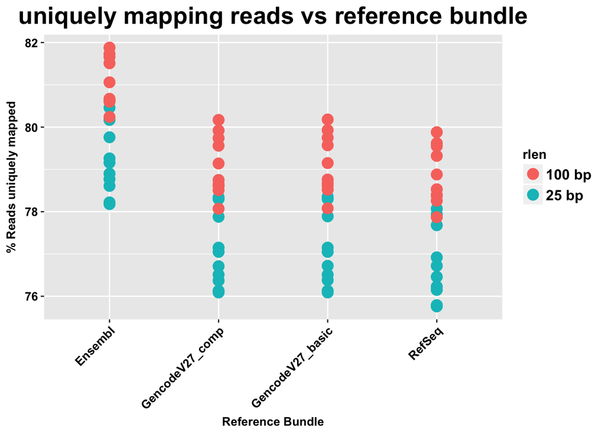

```r
uniq.mapped<-unlist(lapply(ref_log$Uniquely.mapped.reads.., function(x) as.numeric(sub("%", "", x))))
p<-ggplot(data=ref_log)+geom_point(mapping=aes(x=refname,y=uniq.mapped,color=rlen),size=4)
p<-p+xlab('Reference Bundle')+ylab('% Reads uniquely mapped')+ggtitle('uniquely mapping reads vs reference bundle')
p<-p+theme(plot.title = element_text(hjust = 0.5,size=20,face='bold'))
p<-p+theme(axis.title.x = element_text(color='black',size=10,face='bold'),axis.title.y = element_text(size=10,color='black',face='bold'))
p<-p+theme(axis.text.y = element_text(color='black',size=10,face='bold'),axis.text.x = element_text(color='black',size=10,face='bold',hjust=1,angle = 45))
p<-p+theme(legend.text=element_text(size=12,face='bold'),legend.title = element_text(face="bold"))
p
```

Now let’s plot `multiple mapping reads vs reference bundle`. `Ensembl` bundle actually show the lowest multiple mapping rate

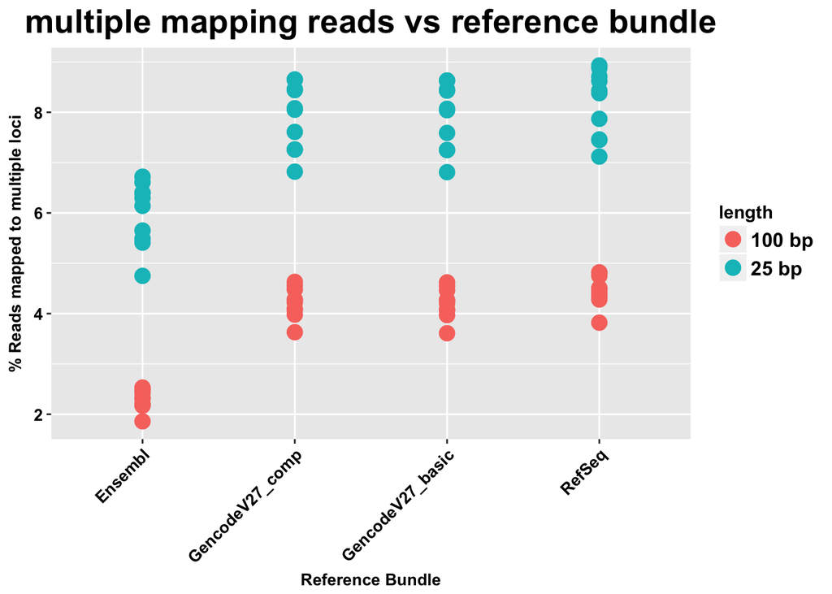

```r
multi.loci<-unlist(lapply(ref_log$X..of.reads.mapped.to.multiple.loci, function(x) as.numeric(sub("%", "", x))))
p<-ggplot(data=ref_log)+geom_point(mapping=aes(x=ref_name,y=multi.loci,color=length),size=4)
p<-p+xlab('Reference Bundle')+ylab('% Reads mapped to multiple loci')+ggtitle('multiple mapping reads vs reference bundle')
p<-p+theme(plot.title = element_text(hjust = 0.5,size=20,face='bold'))
p<-p+theme(axis.title.x = element_text(color='black',size=10,face='bold'),axis.title.y = element_text(size=10,color='black',face='bold'))
p<-p+theme(axis.text.y = element_text(color='black',size=10,face='bold'),axis.text.x = element_text(color='black',size=10,face='bold',hjust=1,angle = 45))
p<-p+theme(legend.text=element_text(size=12,face='bold'),legend.title = element_text(face="bold"))
p
```

Then `reads mapped too many loci vs reference bundle`. `Ensembl` bundle show slightly low rate of `reads mapped too many loci`

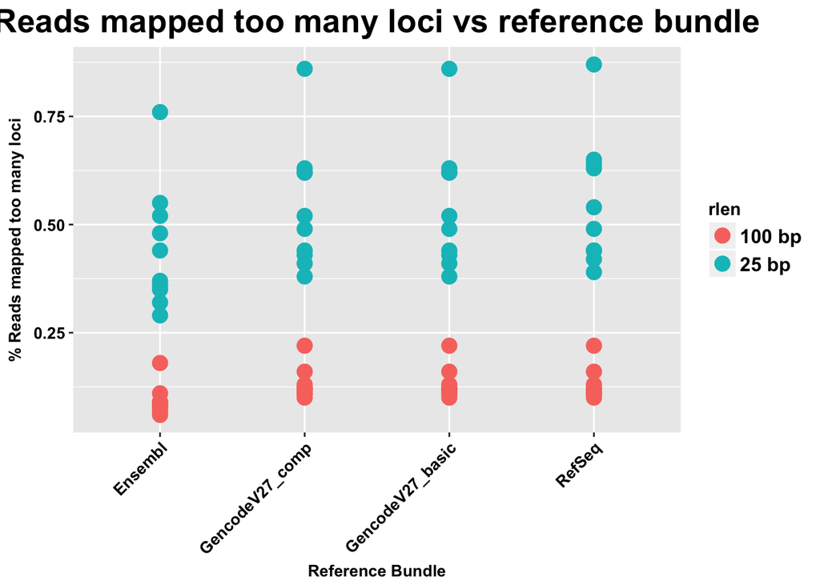

```r
too.many<-unlist(lapply(ref_log$X..of.reads.mapped.to.too.many.loci, function(x) as.numeric(sub("%", "", x))))
p<-ggplot(data=ref_log)+geom_point(mapping=aes(x=refname,y=too.many,color=rlen),size=4)
p<-p+xlab('Reference Bundle')+ylab('% Reads mapped too many loci')+ggtitle('Reads mapped too many loci vs reference bundle')
p<-p+theme(plot.title = element_text(hjust = 0.5,size=20,face='bold'))
p<-p+theme(axis.title.x = element_text(color='black',size=10,face='bold'),axis.title.y = element_text(size=10,color='black',face='bold'))
p<-p+theme(axis.text.y = element_text(color='black',size=10,face='bold'),axis.text.x = element_text(color='black',size=10,face='bold',hjust=1,angle = 45))
p<-p+theme(legend.text=element_text(size=12,face='bold'),legend.title = element_text(face="bold"))
p
```

What if the `annotated splicing junction` ?

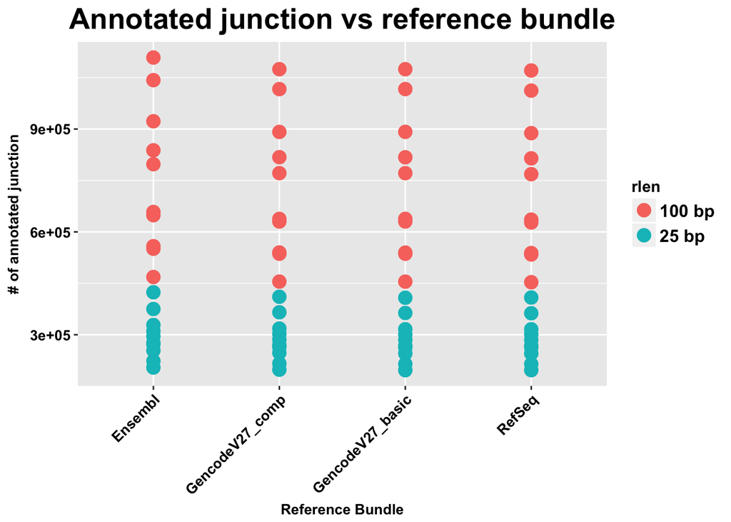

```r
junction<-ref_log$Number.of.splices..Annotated..sjdb.
p<-ggplot(data=ref_log)+geom_point(mapping=aes(x=refname,y=junction,color=rlen),size=4)
p<-p+xlab('Reference Bundle')+ylab('# of annotated junction')+ggtitle('Annotated junction vs reference bundle')
p<-p+theme(plot.title = element_text(hjust = 0.5,size=20,face='bold'))
p<-p+theme(axis.title.x = element_text(color='black',size=10,face='bold'),axis.title.y = element_text(size=10,color='black',face='bold'))
p<-p+theme(axis.text.y = element_text(color='black',size=10,face='bold'),axis.text.x = element_text(color='black',size=10,face='bold',hjust=1,angle = 45))
p<-p+theme(legend.text=element_text(size=12,face='bold'),legend.title = element_text(face="bold"))
p
```

[figure not shown]

```r
splices<-ref_log$Number.of.splices..Total
p<-ggplot(data=ref_log)+geom_point(mapping=aes(x=refname,y=junction,color=rlen),size=4)
p<-p+xlab('Reference Bundle')+ylab('# of Total Splices')+ggtitle('Total Splices vs reference bundle')
p<-p+theme(plot.title = element_text(hjust = 0.5,size=20,face='bold'))
p<-p+theme(axis.title.x = element_text(color='black',size=10,face='bold'),axis.title.y = element_text(size=10,color='black',face='bold'))
p<-p+theme(axis.text.y = element_text(color='black',size=10,face='bold'),axis.text.x = element_text(color='black',size=10,face='bold',hjust=1,angle = 45))
p<-p+theme(legend.text=element_text(size=12,face='bold'),legend.title = element_text(face="bold"))
p
```